# functional_programming_solved

### What do NYTimes opinion writers write about?

NYTimes is one of the left-leaning major national news outlets. It is also one of the news companies that have more successfully transitioned into the digital age.

Similar to most tech companies, NYTimes published a few APIs to query some of its data. In today's exercise, we will focus on the data from their [Archive API](https://developer.nytimes.com/docs/archive-product/1/overview), which stores the metadata on every article published at NYTimes, e.g. author, published time, topics, etc.

Due to limitations on Ed, we've limited the sections to only those in Opinion, New York, Sports, World, U.S., Arts, Business Day.

Our ultimate goal is to group the different opinion writers into different categories depending on the topics they write about. An opinion writer is someone who simply comments on the current events given their background. They may or may not have formal training in the subject they comment about.

```r
library(jsonlite)
arch <- jsonlite::read_json("data/nytimes_archive_202001.json")
```

### Problem 0

- How many articles were published at NYTimes in 2020 January?
- What data type is each record stored as?
- Where can I find the author(s) for each article? Hint, work with just one record to figure out the "structure" of this data.
- Please comment on whether you think the data types are reasonable choices?

```r
# 2725 articles!
length(arch)
```

2725

```r
object.size(arch)
```

```
78373008 bytes
```

```r
class(arch[[1]])
```

'list'

```r
arch[[1]]$byline$person
```

1. **$firstname**

   1. 'Adeel'

   **$middlename**

   **$lastname**

   1. 'Hassan'

   **$qualifier**

   **$title**

   **$role**

   1. 'reported'

   **$organization**

   1. ''

   **$rank**

   1. 1

```r
names(arch[[1]]$byline)
```

1. 'original'

2. 'person'

3. 'organization'

`List` makes sense given:

- the data types include integers (rank) and characters (name).
- Also, the data has a hierarchical structure, for instance, the `keywords` needs different information than `byline` so for all of this to fit under one record, we use lists because it's flexible.

```r
names(arch[[1]])
```

1. 'abstract'

2. 'web_url'

3. 'snippet'

4. 'lead_paragraph'

5. 'print_section'

6. 'print_page'

7. 'source'

8. 'multimedia'

9. 'headline'

10. 'keywords'

11. 'pub_date'

12. 'document_type'

13. 'news_desk'

14. 'section_name'

15. 'byline'

16. 'type_of_material'

17. '_id'

18. 'word_count'

19. 'uri'

### Problm 1

- Please create a vector that contains the respective `section_name` for each article, please do this in 2 ways:
  - Use a for-loop
  - Use purrr::map()
- Please verify that the 2 methods above produce the same answer
- Which method is more readable to you?
- What section (e.g. sports, business, etc) has the most articles? Hint: `table(sample(1:3, 100, replace=TRUE))`
- Please create a subset of the data with only records from the "Opinion" section.

```r
sec_bag1 <- vector('character', length(arch))
for(i in seq_along(arch)){
    sec_bag1[i] <- arch[[i]]$section_name[[1]]
}
```

```r
library(purrr)
```

```r
grab_section <- function(x){
    return(x$section_name[[1]])
}
sec_bag2 <- map_chr(arch, grab_section)
```

```r
arch[[1]]$section_name
```

1. 'U.S.'

```r
head(sec_bag1)
```

1. 'U.S.'

2. 'Arts'

3. 'Opinion'

4. 'Sports'

5. 'World'

6. 'U.S.'

```r
all(sec_bag1 == sec_bag2)
```

TRUE

```r
sub_arch <- arch[sec_bag1 == "Opinion"]
```

```r
length(sub_arch)
```

416

### Problem 2

For the **filtered data**, we want to create a data frame, where the rows correspond to different writers, and the y-axis denotes different "subjects" they write about.

Subjects are under `keywords` with the attribute `name='subject'`. The corresponding `value` would denote the actual subject matter.

- You may want to remove the unfiltered dataset from Ed's memory for now.
- What is the distribution of "number of authors" per article for the Opinion pieces? Please avoid using a for-loop!
- Please decide how you'll record the names (single character string? how will you include the middle name?) and the subjects (e.g. if there are 4 authors who wrote about anti-semitism, do they each get 0.25 or 1, if an author wrote 2 articles under the same subject, what should you do)?
- We sugest you to read plan out the following, then try to divide and conquer for the following methods to obtain the data frame where rows are writers and the columns are different subjects.
  - Use multiple passes, with the first few passes obtaining the full list of the authors and subjects, then the final pass will fill in the matrix.
    - Hint: `unique()` can help you deduplicate things.
    - Hint: `flatten_????` can turn a list into a vector.
    - Hint: `data.frame(matrix(0, nrow=2, ncol=3))`
    - Hint: `letters %in% c('a', 'd')`
  - (OPTIONAL, more challenging) Use 1 pass through the data.
    - Recycle your functions from above, get data frame per record that contains only information for the authors and subjects in that record
    - Use plyr::rbind.fill() to align the columns across the data frames.
    - Use aggregate() to ensure each author only has one row of data. Hint:

      ```
      names_col <- names(df) == "auth_name"
      df <- aggregate(df[, !names_col], by=df[names_col], max)
      ```

- Who wrote the most diverse set of subjects? And how many subjects they write about in January?

```r
rm(arch)
```

```r
table(map_dbl(sub_arch, function(x) length(x$byline$person)))
```

```
  0   1   2   3
102 291  20   3
```

```r
# Which ever is fine, they'll be changing it later :P
```

```r
get_name <- function(person){
    if(length(person$middlename) == 0){
        final_name <- paste(person$firstname, person$lastname)
    } else {
        final_name <- paste(person$firstname,
                            person$middlename,
                            person$lastname)
    }
}
```

```r
get_auth <- function(record){
    people <- record$byline$person
    return(map_chr(people, get_name))
}
```

```r
authors <- sub_arch[[1]]$byline$person
```

```r
get_auth(sub_arch[[59]])
```

1. 'Philip Gordon'

2. 'Ariane Tabatabai'

```r
get_subject <- function(record){
    keywords <- record$keywords
    is_subject <- map_lgl(keywords, function(i) i$name == 'subject')
    out <- map_chr(keywords[is_subject], function(i) i$value[[1]])
    return(out)
}
```

```r
get_subject(sub_arch[[1]])
```

1. 'Diet and Nutrition'

2. 'Exercise'

3. 'Weight'

4. 'Cooking and Cookbooks'

5. 'Calories'

6. 'Preventive Medicine'

7. 'Vaccination and Immunization'

8. 'Sleep'

9. 'Smoking and Tobacco'

```r
authors <- map(sub_arch, get_auth)
subjects <- map(sub_arch, get_subject)
```

```r
uniq_auth <- unique(flatten_chr(authors))
uniq_sub <- unique(flatten_chr(subjects))
```

```r
length(uniq_sub)
```

462

```r
mat <- data.frame(
    matrix(0,
           nrow=length(uniq_auth),
           ncol=length(uniq_sub)))
names(mat) <- uniq_sub
rownames(mat) <- uniq_auth
```

```r
for(article in sub_arch){
    target_auths <- uniq_auth %in% get_auth(article)
    target_subs <- uniq_sub %in% get_subject(article)
    if(sum(target_auths) == 0 | sum(target_subs) == 0) next
    mat[target_auths, target_subs] <- mat[target_auths, target_subs] + 1
}
```

```r
sum(mat > 1)
```

86

```r
get_tiny_mat <- function(record){
    auths <- get_auth(record)
    subs <- get_subject(record)
    tiny_mat <- data.frame(matrix(1, nrow=length(auths),
                                  ncol=length(subs)))
    names(tiny_mat) <- subs
    tiny_mat[['auth_name']] <- auths
    return(tiny_mat)
}
```

```r
dfs <- map(sub_arch, get_tiny_mat)
```

```r
library(plyr)
df <- plyr::rbind.fill(dfs)
```

```r
df[is.na(df)] <- 0
```

```r
names_col <- names(df) == "auth_name"
agg_df <- aggregate(df[, !names_col], by=df[names_col], sum)
```

```r
head(agg_df)
```

| auth_name | Diet and Nutrition | Exercise | Weight | Cooking and Cookbooks | Calories | Preventive Medicine | Vaccination and Immunization | Sleep | Smoking and Tobacco | ⋯ | Hunger Strikes | Running | Marathon Running | New York City Marathon | Football | Super Bowl | Sugar | Asian-Americans | First Amendment (US Constitution) | Government Employees |
| --- | --- | --- | --- | --- | --- | --- | --- | --- | --- | --- | --- | --- | --- | --- | --- | --- | --- | --- | --- | --- |
| Afua Hirsch | 0 | 0 | 0 | 0 | 0 | 0 | 0 | 0 | 0 | ⋯ | 0 | 0 | 0 | 0 | 0 | 0 | 0 | 0 | 0 | 0 |
| Ai Weiwei | 0 | 0 | 0 | 0 | 0 | 0 | 0 | 0 | 0 | ⋯ | 0 | 0 | 0 | 0 | 0 | 0 | 0 | 0 | 0 | 0 |
| Aisha Harris | 0 | 0 | 0 | 0 | 0 | 0 | 0 | 0 | 0 | ⋯ | 0 | 0 | 0 | 0 | 0 | 0 | 0 | 0 | 0 | 0 |
| Alex Berenson | 0 | 0 | 0 | 0 | 0 | 0 | 0 | 0 | 0 | ⋯ | 0 | 0 | 0 | 0 | 0 | 0 | 0 | 0 | 0 | 0 |
| Alex Widdowson | 0 | 0 | 0 | 0 | 0 | 0 | 0 | 0 | 0 | ⋯ | 0 | 0 | 0 | 0 | 0 | 0 | 0 | 0 | 0 | 0 |
| Alexander Agadjanian | 0 | 0 | 0 | 0 | 0 | 0 | 0 | 0 | 0 | ⋯ | 0 | 0 | 0 | 0 | 0 | 0 | 0 | 0 | 0 | 0 |

```r
mean(agg_df[1, -1] == mat[rownames(mat) == "Afua Hirsch", ])
```

1

```r
all(names(agg_df)[-1] == names(mat))
```

TRUE

```r
length(subjects)
```

416

```r
length(flatten_chr(subjects))
```

1616

```r
topics_wrote <- apply(agg_df[, -1], 1, function(x) sum(x > 0))
```

```r
agg_df[which.max(topics_wrote), 1]
```

'David Leonhardt'

```r
sum(agg_df[which.max(topics_wrote), -1] > 0)
```

42

```r
david_stat <- agg_df[which.max(topics_wrote), ]
david_stat[,david_stat > 0]
```

|  | auth_name | Primaries and Caucuses | Voting and Voters | United States Politics and Government | Politics and Government | Surveillance of Citizens by Government | Defense and Military Forces | Targeted Killings | United States International Relations | United States Defense and Military Forces | ⋯ | Consumer Behavior | Infrastructure (Public Works) | Gross Domestic Product | Mobile Commerce and Payments | Conservatism (US Politics) | Ethics and Official Misconduct | Democracy (Theory and Philosophy) | Crime and Criminals | Rural Areas | Amnesties, Commutations and Pardons |
| --- | --- | --- | --- | --- | --- | --- | --- | --- | --- | --- | --- | --- | --- | --- | --- | --- | --- | --- | --- | --- | --- |
| 46 | David Leonhardt | 4 | 4 | 14 | 2 | 1 | 1 | 1 | 2 | 1 | ⋯ | 1 | 1 | 1 | 1 | 1 | 1 | 1 | 1 | 1 | 1 |

#### Problem 3

- What is the dimension of your final data frame from above?
- Write a function, `sim_factory` that can output different "similarity" measures between the authors, measured across the topics they write about. These simiarity measures should take in 2 authors names, then output their similarity score (not the data frame from above, i.e. the data frame needs to be included in definition of `sim_factory()`).
  - Naive similiarty measure: $$sim(X, Y) = \frac{1}{p}\sum_i 1[X_i = Y_i]$$ where $p$ is the length of $X$ and $Y$.
  - Cosine similarity $$cos_sim(X, Y) = \frac{X\cdot Y}{\|X\|\|Y\|} = \frac{\sum_i X_i Y_i}{\sqrt{\sum_i X_i^2 \sum_i Y_i^2}}$$
- Use the functions from above to calculate the similarity between each author to the most diverse writer. Please plot this outcome. Hint: `plot(sim_scores)`.
- Comment on the 2 similarity scores, which one do you like better?

```r
sim_factory <- function(f){
    sim_met <- function(x, y){
        auth1 <- agg_df$auth_name == x
        auth2 <- agg_df$auth_name == y
        return(f(agg_df[auth1, -1],
                 agg_df[auth2, -1]))
    }
    return(sim_met)
}
```

```r
naive_sim <- function(x, y){
    return(mean(x == y))
}
cosin_sim <- function(x, y){
    return(sum(x * y) / sqrt(sum(x^2) * sum(y^2)))
}
```

```r
sim_funs <- c(naive=naive_sim, cos=cosin_sim)
sims <- map(sim_funs, sim_factory)
```

```r
names(sims)
```

1. 'naive'

2. 'cos'

```r
auth_pairs <- expand.grid(agg_df$auth_name, agg_df$auth_name)
```

```r
head(auth_pairs)
```

| Var1 | Var2 |
| --- | --- |
| Afua Hirsch | Afua Hirsch |
| Ai Weiwei | Afua Hirsch |
| Aisha Harris | Afua Hirsch |
| Alex Berenson | Afua Hirsch |
| Alex Widdowson | Afua Hirsch |
| Alexander Agadjanian | Afua Hirsch |

```r
auth1 <- auth_pairs[2, 1]
auth2 <- auth_pairs[2, 2]
```

```r
sims[["cos"]](auth1, auth2)
sims[["naive"]](auth1, auth2)
```

0

0.980519480519481

```r
# Yes, I know this isn't fast....
sim_scores <- lapply(sims, function(sf){
    map_dbl(uniq_auth, function(x) sf(x, "David Leonhardt"))})
```

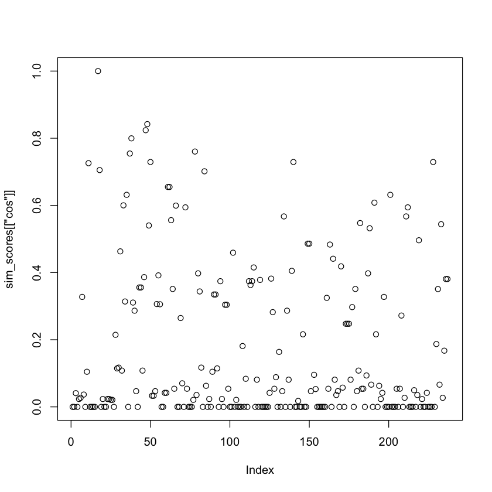

```r
plot(sim_scores[["cos"]])
```

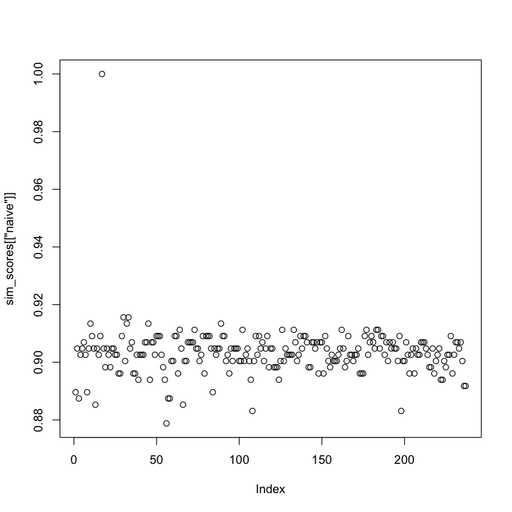

```r
plot(sim_scores[["naive"]])
```